# Part I - (prosper Loan Data)

## by (ojiaku triumph chizaram)

## Introduction

> This data set contains 113,937 loans with 81 variables on each loan, including loan amount, borrower rate (or interest rate), current loan status, borrower income, and many others.

## Preliminary Wrangling

```python
# import all packages and set plots to be embedded inline
import numpy as np
import pandas as pd
import matplotlib.pyplot as plt
import seaborn as sb
import warnings

warnings.filterwarnings('ignore')

%matplotlib inline
```

> Load in your dataset and describe its properties through the questions below. Try and motivate your exploration goals through this section.

```python
# load data SET
data=pd.read_csv('prosperLoanData.csv')
```

### high-level overview of data shape and composition

```python
# overview of data shape
print(data.shape)
```

```
(113937, 81)
```

```python
# overview of data types
print(data.dtypes)
```

```
ListingKey                      object
ListingNumber                    int64
ListingCreationDate             object
CreditGrade                     object
Term                             int64
                                ...
PercentFunded                  float64
Recommendations                  int64
InvestmentFromFriendsCount       int64
InvestmentFromFriendsAmount    float64
Investors                        int64
Length: 81, dtype: object
```

```python
# overview of data
print(data.head(10))
```

```
                ListingKey  ListingNumber            ListingCreationDate  \
0  1021339766868145413AB3B         193129  2007-08-26 19:09:29.263000000
1  10273602499503308B223C1        1209647  2014-02-27 08:28:07.900000000
2  0EE9337825851032864889A          81716  2007-01-05 15:00:47.090000000
3  0EF5356002482715299901A         658116  2012-10-22 11:02:35.010000000
4  0F023589499656230C5E3E2         909464  2013-09-14 18:38:39.097000000
5  0F05359734824199381F61D        1074836  2013-12-14 08:26:37.093000000
6  0F0A3576754255009D63151         750899  2013-04-12 09:52:56.147000000
7  0F1035772717087366F9EA7         768193  2013-05-05 06:49:27.493000000
8  0F043596202561788EA13D5        1023355  2013-12-02 10:43:39.117000000
9  0F043596202561788EA13D5        1023355  2013-12-02 10:43:39.117000000

  CreditGrade  Term LoanStatus           ClosedDate  BorrowerAPR  \
0           C    36  Completed  2009-08-14 00:00:00      0.16516
1         NaN    36    Current                  NaN      0.12016
```

[output cut: 58 more lines]

```python
usable_data = ['LoanOriginalAmount', 'BorrowerAPR', 'BorrowerRate','StatedMonthlyIncome', 'Term', 'ProsperRating (Alpha)', "ProsperScore",
        'EmploymentStatus','ListingCreationDate','Occupation','AvailableBankcardCredit','CreditGrade',"DebtToIncomeRatio",'Investors','LoanStatus']
available_data = data[usable_data]
```

```python
available_data.head()
```

|  | LoanOriginalAmount | BorrowerAPR | BorrowerRate | StatedMonthlyIncome | Term | ProsperRating (Alpha) | ProsperScore | EmploymentStatus | ListingCreationDate | Occupation | AvailableBankcardCredit | CreditGrade | DebtToIncomeRatio | Investors | LoanStatus |
| --- | --- | --- | --- | --- | --- | --- | --- | --- | --- | --- | --- | --- | --- | --- | --- |
| 0 | 9425 | 0.16516 | 0.1580 | 3083.333333 | 36 | NaN | NaN | Self-employed | 2007-08-26 19:09:29.263000000 | Other | 1500.0 | C | 0.17 | 258 | Completed |
| 1 | 10000 | 0.12016 | 0.0920 | 6125.000000 | 36 | A | 7.0 | Employed | 2014-02-27 08:28:07.900000000 | Professional | 10266.0 | NaN | 0.18 | 1 | Current |
| 2 | 3001 | 0.28269 | 0.2750 | 2083.333333 | 36 | NaN | NaN | Not available | 2007-01-05 15:00:47.090000000 | Other | NaN | HR | 0.06 | 41 | Completed |
| 3 | 10000 | 0.12528 | 0.0974 | 2875.000000 | 36 | A | 9.0 | Employed | 2012-10-22 11:02:35.010000000 | Skilled Labor | 30754.0 | NaN | 0.15 | 158 | Current |
| 4 | 15000 | 0.24614 | 0.2085 | 9583.333333 | 36 | D | 4.0 | Employed | 2013-09-14 18:38:39.097000000 | Executive | 695.0 | NaN | 0.26 | 20 | Current |

```python
# descriptive statistics for numeric variables
available_data.describe()
```

|  | LoanOriginalAmount | BorrowerAPR | BorrowerRate | StatedMonthlyIncome | Term | ProsperScore | AvailableBankcardCredit | DebtToIncomeRatio | Investors |
| --- | --- | --- | --- | --- | --- | --- | --- | --- | --- |
| count | 113937.00000 | 113912.000000 | 113937.000000 | 1.139370e+05 | 113937.000000 | 84853.000000 | 106393.000000 | 105383.000000 | 113937.000000 |
| mean | 8337.01385 | 0.218828 | 0.192764 | 5.608026e+03 | 40.830248 | 5.950067 | 11210.225447 | 0.275947 | 80.475228 |
| std | 6245.80058 | 0.080364 | 0.074818 | 7.478497e+03 | 10.436212 | 2.376501 | 19818.361309 | 0.551759 | 103.239020 |
| min | 1000.00000 | 0.006530 | 0.000000 | 0.000000e+00 | 12.000000 | 1.000000 | 0.000000 | 0.000000 | 1.000000 |
| 25% | 4000.00000 | 0.156290 | 0.134000 | 3.200333e+03 | 36.000000 | 4.000000 | 880.000000 | 0.140000 | 2.000000 |
| 50% | 6500.00000 | 0.209760 | 0.184000 | 4.666667e+03 | 36.000000 | 6.000000 | 4100.000000 | 0.220000 | 44.000000 |
| 75% | 12000.00000 | 0.283810 | 0.250000 | 6.825000e+03 | 36.000000 | 8.000000 | 13180.000000 | 0.320000 | 115.000000 |
| max | 35000.00000 | 0.512290 | 0.497500 | 1.750003e+06 | 60.000000 | 11.000000 | 646285.000000 | 10.010000 | 1189.000000 |

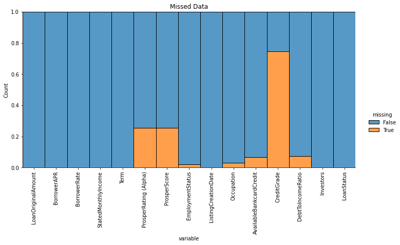

```python
sb.displot(
    data=available_data.isna().melt(value_name="missing"),
    x="variable",
    hue="missing",
    multiple="fill",
    aspect=2
);
plt.xticks(rotation=90)
plt.title('Missed Data');
```

### What is the structure of your dataset?

This data set contains 113,937 loans with 81 variables on each loan, including loan amount, borrower rate (or interest rate), current loan status, borrower income, and many others

### What is/are the main feature(s) of interest in your dataset?

> I'm most interested in figuring out what features are best for predicting borrower's Annual Percentage Rate (Borrower APR) for the loan and affecting the employment zstatus.

### What features in the dataset do you think will help support your investigation into your feature(s) of interest?

I gathered data and all the required informations from 'LoanOriginalAmount', 'BorrowerAPR', 'BorrowerRate,'StatedMonthlyIncome', 'Term', 'ProsperRating (Alpha)', "ProsperScore" 'EmploymentStatus','ListingCreationDate','Occupation','AvailableBankcardCredit','CreditGrade',"DebtToIncomeRatio"

## Univariate Exploration

> In this section, investigate distributions of individual variables. If you see unusual points or outliers, take a deeper look to clean things up and prepare yourself to look at relationships between variables.

```python
# Convert ProsperRating to an ordered type
rate_order = ['HR','E','D','C','B','A','AA']
ordered_var = pd.api.types.CategoricalDtype(ordered = True, categories = rate_order)
available_data.loc[:,'ProsperRating (Alpha)'] = available_data.loc[:,'ProsperRating (Alpha)'].astype(ordered_var, copy=True)
```

```python
# Convert  Employment status to an ordered type
employment_order = ['Employed','Self-employed','Full-time','Part-time','Retired','Other','Not employed', 'Not available']
ordered_var = pd.api.types.CategoricalDtype(ordered = True, categories = employment_order)
available_data.loc[:,'EmploymentStatus'] = available_data.loc[:,'EmploymentStatus'].astype(ordered_var, copy=True)
```

```python
# Choose the first tuple of RGB colors
base_color = sb.color_palette()[0]
```

# plot for Count of Occupation selected by the Borrower

Occupation: The Occupation selected by the Borrower at the time they created the listing.

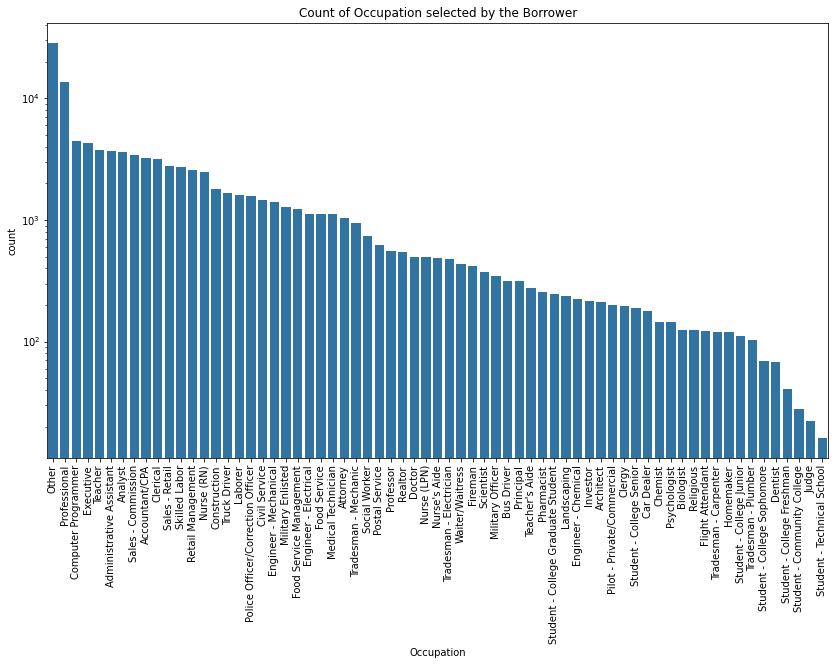

```python
plt.subplots(figsize = [14,8])
type_order = available_data['Occupation'].value_counts().index
g = sb.countplot(data=available_data, x='Occupation', color=base_color, order=type_order);
plt.xticks(rotation=90)
plt.title('Count of Occupation selected by the Borrower');
g.set(yscale="log");
```

from the plot above, it is seen that "other" types of occupation takes more loean and students of techincal school takes less loan.

Next up,

> **loanStatus**: The current status of the loan: Cancelled, Chargedoff, Completed, Current, Defaulted, FinalPaymentInProgress, PastDue. The PastDue status will be accompanied by a delinquency bucket..

### plot for loanStatus

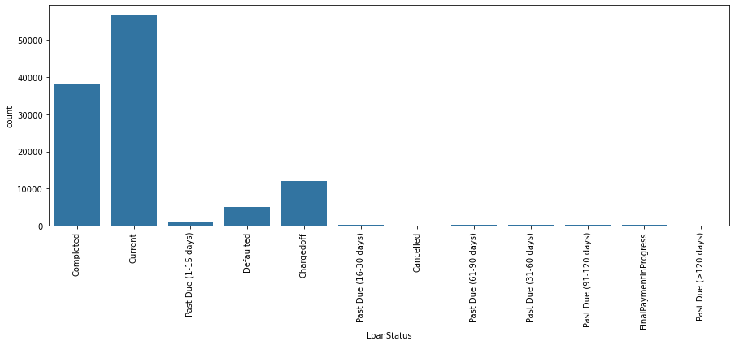

```python
plt.figure(figsize=(15,5))
sb.countplot(data=data, x='LoanStatus', color=base_color);
plt.xticks(rotation=90);
```

Majority of the borrowers has either completed or is still pay his/her loan debt

Next up, the first predictor variable of interest: BorrowerAPR and BorrowerRate

> **BorrowerAPR** : The Borrower's Annual Percentage Rate (APR) for the loan.  
> **BorrowerRate** : The Borrower's interest rate for this loan.

# plot for BorrowerAPR count

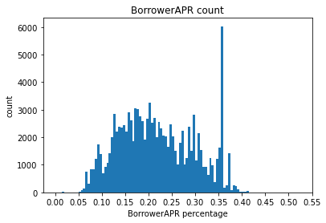

```python
# plot for  BorrowerAPR count
bins = np.arange(0, available_data['BorrowerAPR'].max(), 0.005)
plt.hist(data = available_data, x = 'BorrowerAPR', bins = bins)
plt.title('BorrowerAPR count')
plt.xlabel('BorrowerAPR percentage')
plt.ylabel('count')
plt.xticks(np.arange(0, available_data['BorrowerAPR'].max()+0.05, 0.05));
```

as seen from the plot, 0.35 has more borrowers Annual Percentage Rate (APR) count than others.

# Plot the distribution of BorrowerRate count

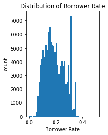

```python
# Plot the distribution of BorrowerRate count
plt.subplot(1, 2, 2)
rate_bins = np.arange(available_data['BorrowerRate'].min(), available_data.BorrowerRate.max()+0.01, 0.01)
plt.hist(data=available_data, x='BorrowerRate', bins=rate_bins)
plt.xlabel('Borrower Rate');
plt.ylabel('count');
plt.title('Distribution of Borrower Rate');
```

BorrowerRate: There is roughly one normal distribution with two exceptional high counts between 0.2 and 0.4 for Distribution of Borrower Rate

**next**,

ProsperRating (Alpha): The Prosper Rating assigned at the time the listing was created between AA - HR. Applicable for loans originated after July 2009.

# Plot for Prosper Rating

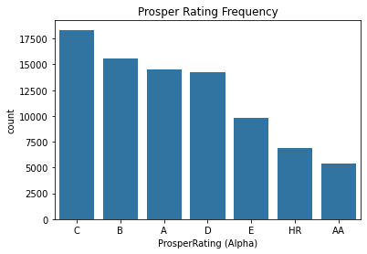

```python
# Plot the Prosper Rating
type_order = available_data['ProsperRating (Alpha)'].value_counts().index
sb.countplot(data=available_data, x='ProsperRating (Alpha)', color=base_color, order=type_order);
plt.ylabel('count');
plt.title('Prosper Rating Frequency');
plt.figsize=(12,12)
```

next,

The Prosper Rating assigned at the time the listing was created: 0 - N/A, 1 - HR, 2 - E, 3 - D, 4 - C, 5 - B, 6 - A, 7 - AA. Applicable for loans originated after July 2009.

# plot to see which ProsperScore received the most count.

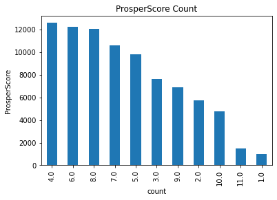

```python
# plot to see which ProsperScore received the most count.

available_data['ProsperScore'].value_counts().plot(kind='bar')
plt.title('ProsperScore Count')
plt.xlabel('count')
plt.ylabel('ProsperScore')
plt.fontsize = 12
plt.figsize=(12,12)
```

A high percentage of the data has it's ProsperScore between 4.0 and 8.0. With the highest population having a prosperscore of 4

up next,

The employment status of the borrower at the time they posted the listing.

# Plot for Employment Status

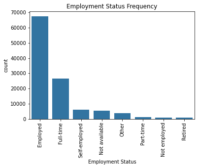

```python
# Plot for Employment Status
type_order = available_data['EmploymentStatus'].value_counts().index
sb.countplot(data=available_data, x='EmploymentStatus', color=base_color, order=type_order);
plt.xticks(rotation = 90);
plt.xlabel('Employment Status');
plt.title('Employment Status Frequency');
```

from the plot above, it is seen that employed has the highest Employment Status Frequency followered by full-time.

up next,

**DebtToIncomeRatio**: The debt to income ratio of the borrower at the time the credit profile was pulled. This value is Null if the debt to income ratio is not available. This value is capped at 10.01 (any debt to income ratio larger than 1000% will be returned as 1001%).

# plot Distribution of the Debt to income Ratio

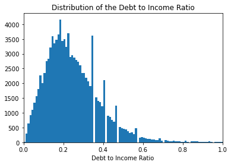

```python
#plot Distribution of the Debt to income Ratio
in_bins = np.arange(available_data.DebtToIncomeRatio.min(), available_data.DebtToIncomeRatio.max()+0.01, 0.01)
plt.hist(data=available_data, x='DebtToIncomeRatio', bins=in_bins);
plt.xlim(0,1);
plt.xlabel('Debt to Income Ratio');
plt.title('Distribution of the Debt to Income Ratio');
```

up next,

**Term**: The length of the loan expressed in months.

# Plot for Term

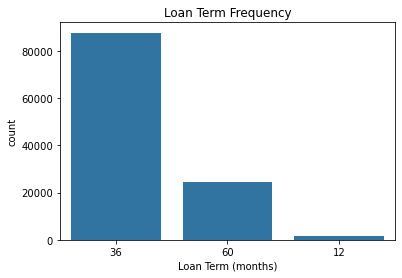

```python
# Plot the Term
type_order = available_data['Term'].value_counts().index
sb.countplot(data=available_data, x='Term', color=base_color, order=type_order);
plt.xlabel('Loan Term (months)');
plt.title('Loan Term Frequency');
```

### Of the features you investigated, were there any unusual distributions? Did you perform any operations on the data to tidy, adjust, or change the form of the data? If so, why did you do this?

> In occpution chart, I observed the huge variance between highest and lowest counts. I used Log Scale for my chart

## Bivariate Exploration

> In this section, investigate relationships between pairs of variables in your data. Make sure the variables that you cover here have been introduced in some fashion in the previous section (univariate exploration).

# correlation plot

**What's pairwise correlations present between features in the data?**

```python
numeric_vars = available_data.select_dtypes(include='number').columns
categoric_vars = ['EmploymentStatus', 'Term', 'ProsperRating (Alpha)']
```

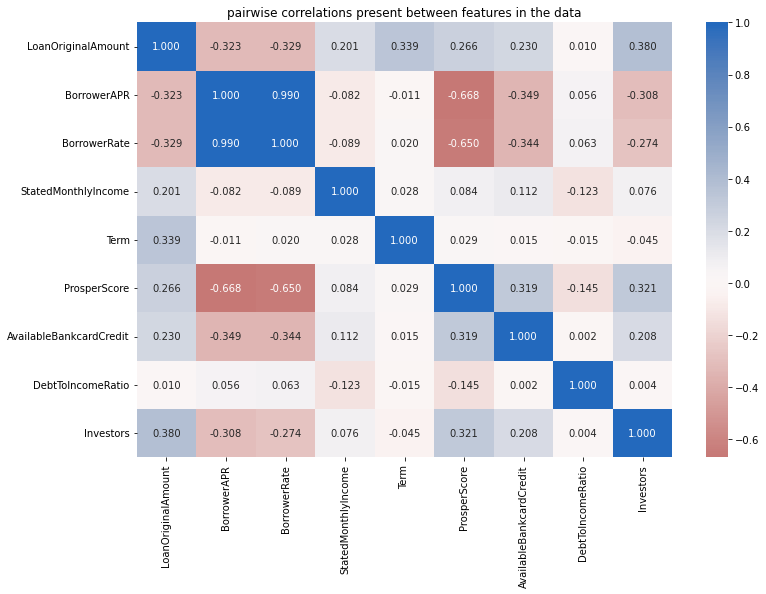

```python
# plotting correlation data
plt.figure(figsize = [12, 8])
sb.heatmap(available_data[numeric_vars].corr(), annot = True, fmt = '.3f',
           cmap = 'vlag_r', center = 0)
plt.title("pairwise correlations present between features in the data")
plt.show()
```

# plotting relation between Loan Original Amount and BorrowerRate

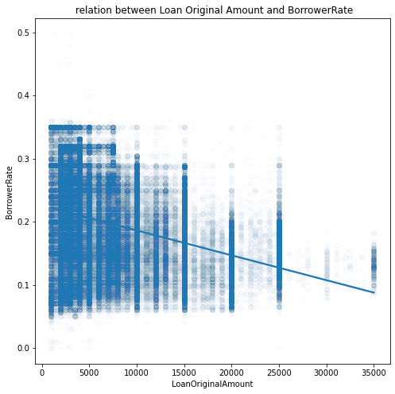

```python
# plotting relation between Loan Original Amount and BorrowerRate.
plt.figure(figsize = [8, 8])
sb.regplot(data = available_data, x = 'LoanOriginalAmount', y = 'BorrowerRate', scatter_kws={'alpha':1/80});
plt.title(" relation between Loan Original Amount and BorrowerRate");
```

from the plot, it is seen that at different sizes of the total loan amount, the borrower's rate has a large distribution, but the range of borrowers rate decreases with the increase of loan amount. So the borrower's rate is negatively correlated with the total loan amount.

next

**What's relationship between EmploymentStatus and ProsperScore ?**

# plotting common Employment Status in each Prosper score

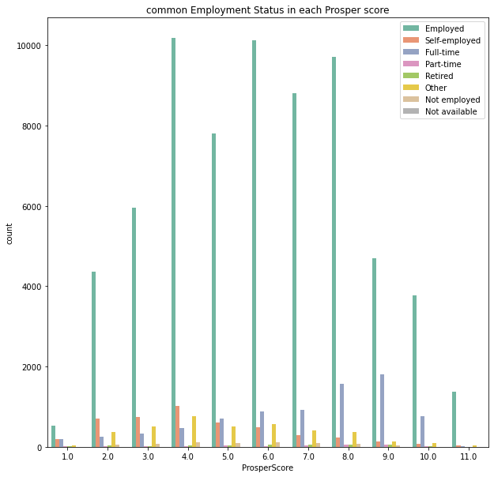

```python
#plotting common Employment Status in each Prosper score

plt.figure(figsize = [10, 10])
sb.countplot(data=available_data, x='ProsperScore', hue='EmploymentStatus', palette='Set2');
plt.legend(loc=1);
plt.title("common Employment Status in each Prosper score");
```

from the plot above, it is seen that Employed people has more prosper score than other employment status

next

# plot matrix:

```
available_data.shape= (113937, 15)
 available_data_samp.shape= (500, 15)
```

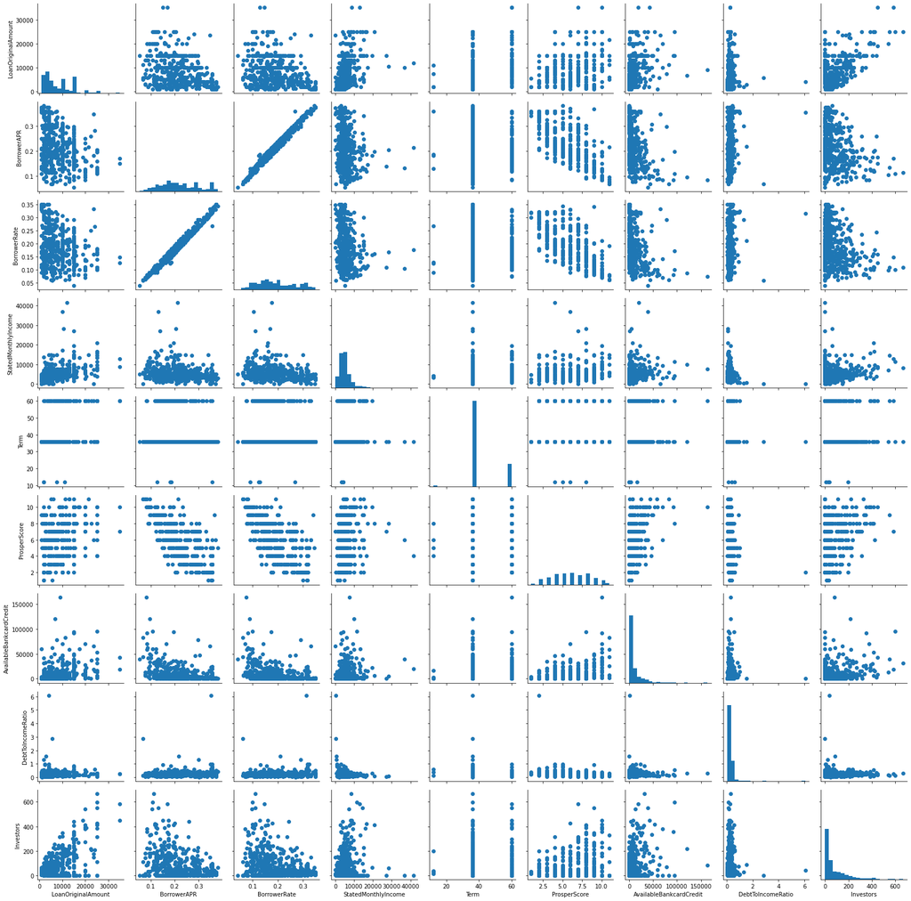

```python
# plot matrix: sample 500 loan so that plots are clearer and they render faster
print("available_data.shape=",available_data.shape)
available_data_samp = available_data.sample(n=500, replace = False)
print(" available_data_samp.shape=", available_data_samp.shape)

g = sb.PairGrid(data =  available_data_samp, vars = numeric_vars)
g = g.map_diag(plt.hist, bins = 20);
g.map_offdiag(plt.scatter)
```

up next,

**How BorrowerRate & ProsperScore behavior with categorical features?**

# plot matrix of numeric features against categorical features using box plot

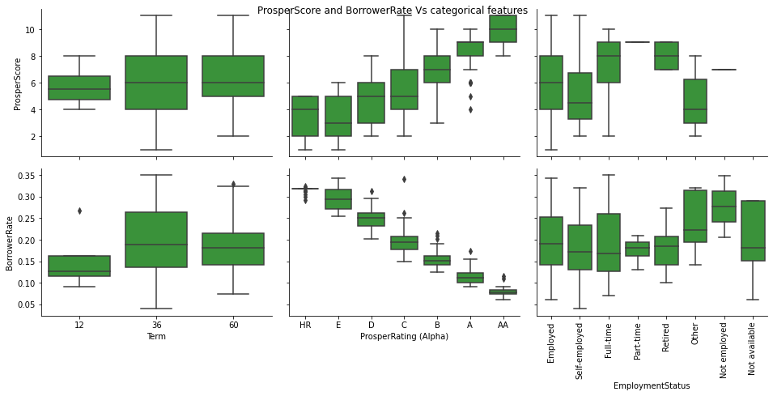

```python
# plot matrix of numeric features against categorical features.

def boxgrid(x, y, **kwargs):
    """ Quick hack for creating box plots with seaborn's PairGrid. """
    default_color = sb.color_palette()[2]
    sb.boxplot(x, y, color = default_color)


g = sb.PairGrid(data = available_data_samp, y_vars = ['ProsperScore','BorrowerRate'
],x_vars = ['Term', 'ProsperRating (Alpha)', 'EmploymentStatus'], height = 3, aspect = 1.5)

g.map(boxgrid);
plt.xticks(rotation=90);
g.fig.suptitle('ProsperScore and BorrowerRate Vs categorical features');
plt.show();
```

looking at the result gotten from the box plot, it was observerd that the distribution of different credit risks and the BorrowerRate is that there is a negative correlation between having a higher score and a lower interest rate.

next

**What's relationship between Term and the CreditGrade/ProsperRating(s) and ProsperScore ?**

# plotting Term in EmploymentStatus/ProsperRating(s) and ProsperScore

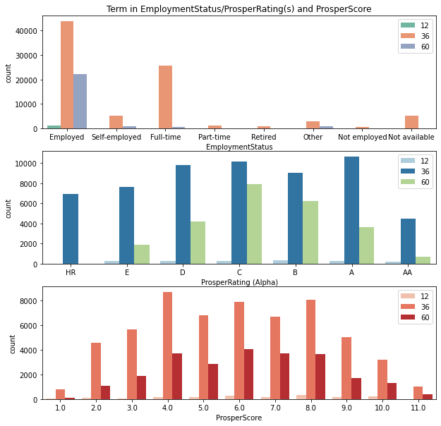

```python
# plotting Term in EmploymentStatus/ProsperRating(s) and ProsperScore

plt.figure(figsize=[10,10])

plt.subplot(3,1,1)
sb.countplot(data=available_data, x='EmploymentStatus', hue='Term', palette='Set2');
plt.legend(loc=1);
plt.title("Term in EmploymentStatus/ProsperRating(s) and ProsperScore");

plt.subplot(3,1,2)
sb.countplot(data=available_data, x='ProsperRating (Alpha)', hue='Term', palette='Paired');
plt.legend(loc=1);


plt.subplot(3,1,3)
sb.countplot(data=available_data, x='ProsperScore', hue='Term', palette='Reds');
plt.legend(loc=1);
```

from the chart,it was observerd that employed from employmentStatus has more length of the loan expressed in months of 60.

# relationship between EmploymentStatus and loanstatus

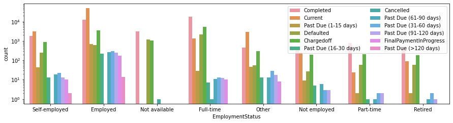

```python
plt.figure(figsize = [15, 8])

plt.subplot(2, 1, 1)
sb.countplot(data = data, x = 'EmploymentStatus', hue = 'LoanStatus');
plt.yscale('log');
plt.legend(loc=1, ncol = 2);
```

next

whats the correlation between (EmploymentStatus, the ProsperRating, and ProsperScore) to BorrowerAPR using violin plot?

# correlation between (EmploymentStatus, the ProsperRating, and ProsperScore) to BorrowerAPR using violin plot

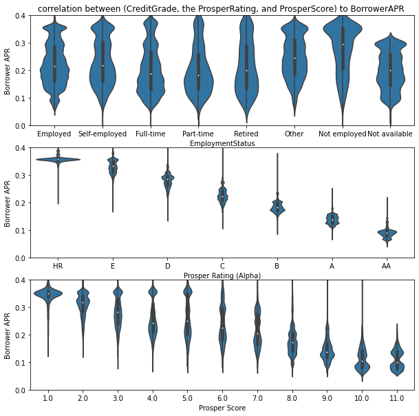

```python
# correlation between (CreditGrade, the ProsperRating, and ProsperScore) to BorrowerAPR using violin plot

plt.figure(figsize=[10,10])
plt.subplot(3,1,1)
sb.violinplot(data=available_data, x='EmploymentStatus', y='BorrowerAPR', color=base_color);
plt.ylim((0,0.4));
plt.xlabel("EmploymentStatus");
plt.ylabel("Borrower APR");
plt.title("correlation between (CreditGrade, the ProsperRating, and ProsperScore) to BorrowerAPR ");

plt.subplot(3,1,2)
sb.violinplot(data=available_data, x='ProsperRating (Alpha)', y='BorrowerAPR', color=base_color);
plt.ylim((0,0.4));
plt.xlabel("Prosper Rating (Alpha)");
plt.ylabel("Borrower APR");

plt.subplot(3,1,3)
sb.violinplot(data=available_data, x='ProsperScore', y='BorrowerAPR', color=base_color);
plt.ylim((0,0.4));
plt.xlabel("Prosper Score");
plt.ylabel("Borrower APR");
```

in the violin plot above, there is a negative correlation between having a higher score and a lower interest rate. With ProsperScore there is still a decline, but the distribution of the BorrowerRate is more distributed and the IQR is generally larger for each rating.

### Talk about some of the relationships you observed in this part of the investigation. How did the feature(s) of interest vary with other features in the dataset?

> i also observed that the different sizes of the total loan amount, the borrower's APR has a large distribution, but the range of APR decreases with the increase of loan amount. So the borrower's APR is negatively correlated with the total loan amount.

## Multivariate Exploration

> Create plots of three or more variables to investigate your data even further. Make sure that your investigations are justified, and follow from

your work in the previous sections.

# plotting Borrower APR across rating and EmploymentStatus

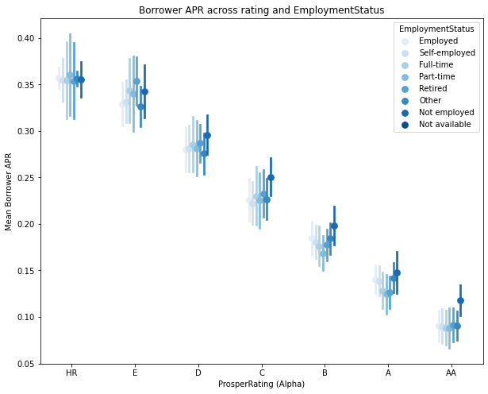

```python
# plotting Borrower APR across rating and EmploymentStatus
plt.figure(figsize = [10,8])
sb.pointplot(data = available_data, x = 'ProsperRating (Alpha)', y = 'BorrowerAPR', hue = 'EmploymentStatus',
           palette = 'Blues', linestyles = '', dodge = 0.4, ci='sd')
plt.title('Borrower APR across rating and EmploymentStatus')
plt.ylabel('Mean Borrower APR');
```

# plotting stated monthly income and loan original amount variables effect on EmploymentStatus

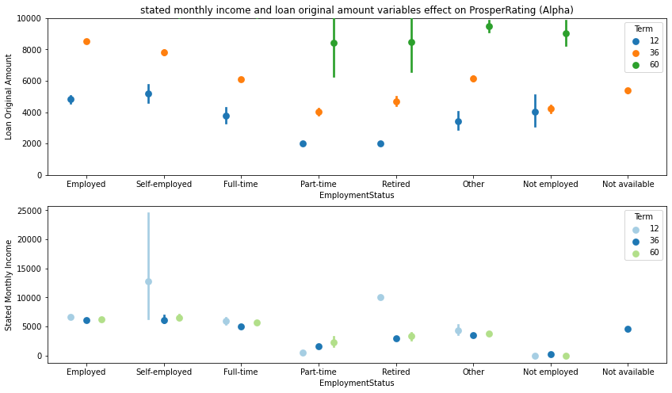

```python
# plotting stated monthly income and loan original amount variables effect on ProsperRating (Alpha)
plt.figure(figsize=[14,8])
plt.title('rating and the term affect on stated monthly income and loan original amount');
plt.subplot(2,1,1)
sb.pointplot(data = available_data, x = 'EmploymentStatus', y = 'LoanOriginalAmount', hue = 'Term',
           palette = 'tab10', linestyles = '', dodge = 0.4)
plt.title("stated monthly income and loan original amount variables effect on ProsperRating (Alpha)");
plt.xlabel("EmploymentStatus");
plt.ylabel("Loan Original Amount");

plt.ylim(0,10000);
plt.subplot(2,1,2)
sb.pointplot(data = available_data, x = 'EmploymentStatus', y = 'StatedMonthlyIncome', hue = 'Term',
           palette = 'Paired', linestyles = '', dodge = 0.4);
plt.xlabel("EmploymentStatus");
plt.ylabel("Stated Monthly Income");
```

from the plot, the pattern of the term is all most similar among different EmploymentStatus, but has high upshot for self-employed for stated monthly income. But for the loan amount, there is an interaction between term and Loan Original Amount .

what is the distribution between loanstatus, BorrowerAPR and EmploymentStatus??

# plot for the distribution between loanstatus, BorrowerAPR and EmploymentStatus

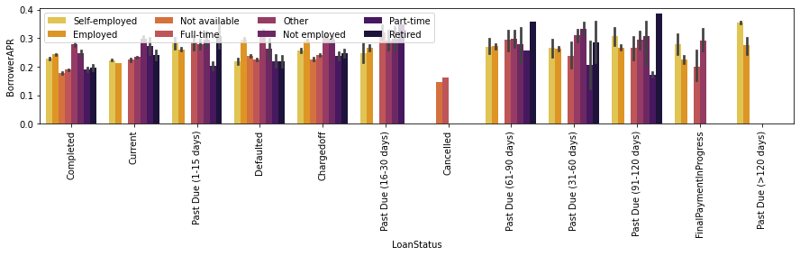

```python
plt.figure(figsize = [15, 8])

plt.subplot(3, 1, 1)
sb.barplot(data = data, x = 'LoanStatus', y='BorrowerAPR', hue = 'EmploymentStatus', palette = 'inferno_r');
plt.xticks(rotation=90)
plt.legend(loc=2, ncol = 4)
```

### Talk about some of the relationships you observed in this part of the investigation. Were there features that strengthened each other in terms of looking at your feature(s) of interest?

> The correlation and matrix plots in previous plots can also be counted as part of Multivariate Exploration. To be more efficient, these two plots can be done ealier part of exploration to preview all variables and how they interact to each other

>

### Were there any interesting or surprising interactions between features?

> From all above visualizations created from univariate exploration to multivariate exploration, many variable are found to be negatively correlated to BorrowerAPR, whereas ProspoerScore gives the strongest negative relationship.

## Conclusions

> Employed from EmploymentStatus has the higest percentage of all the data compared to it.